# Functional Data Analyis for Covid in Europe

Eliott Van Dieren

2023-05-27

# 1 Introduction

Since early 2020, COVID-19 has had a profound impact on the entire world. Scientists tried to analyse the various death, cases and hospitalization curves to protect the population via different sanitary measures such as lockdowns, social distancing and mask wearing. Those methods were put in place in order to “flatten the curve”, and avoid peaks of population in hospitals.

In this project, we focus on the first wave in European countries, and more precisely on the curve of covid cases across those countries. From those curves, we try to identify common divergence patterns from the mean. Practically, this can be done using Functional Principal Component Analysis, where principal components are functions and each covid curve will be a linear combination of those functions on top of the mean from the selected countries covid cases.

Regarding the plan of this project, we first start by a description of the dataset and basic transformations. Second, we explore B-Splines smoothing and prepare our data for the functional PCA computation, which will be the third section of this report. Lastly, we conclude by reporting the take-home messages and next steps. I want to point out that the majority of the reflection on this project has been made with Candice Baud, another Applied Stats student at EPFL. However, the writing of the report and the coding parts are individual work.

# 2 Data exploration

## 2.1 Dataset Description

The [dataset](https://github.com/owid/covid-19-data/blob/master/public/data/owid-covid-data.csv) used in this project is made of worldwide daily data about the covid pandemic. Each row describe more than $50$ covid-related variables for a given day, in a given country. As the dataset contains $67$ columns, we will only describe the ones we will use in this project.

- `continent`: Continent of the daily observation
- `location`: Country name
- `date`: Date of the measurements
- `new_cases_per_million`: Number of new covid cases per million of citizens at `date` in `location`
- `total_cases_per_million`: Cumulative number of covid cases per million of citizens up to `date` in `location`

From all European countries, we decided to remove the ones with a population less than five million people. This is justified as we are working with cases per million, and therefore each country will further down have the same weight. However, we think that a country like France with more than 65 million people should not be compared with a country like Luxembourg which only has 640 thousands citizens. We further removed Belarus and Russia due to polemical covid cases reports from the authorities. Lastly, we removed all countries which had more than five percent of missing values in `total_cases_per_million`. With all those removals, we went from $51$ countries to $24$. Hereunder is a plot of the log-cumulative number of covid cases for each country.

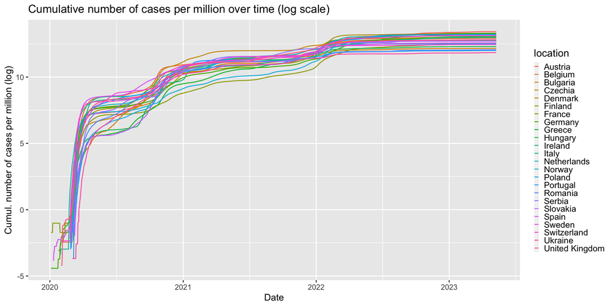

## 2.2 Data transformation

With those $24$ remaining countries, we can now try to find the first wave of covid in each of them. To do so, we first computed for each country, the date when the total number of cases per million exceeded $25$ people (arbitrary but ended with good results). Then, we found when looking at various articles, that the first wave in Europe finished around the start of June $2020$. Therefore, we got for each country, a starting date and an end date (first of June $2020$). Hereunder the new cases per million of people are plotted, for each country from their start date to the first of June 2020.

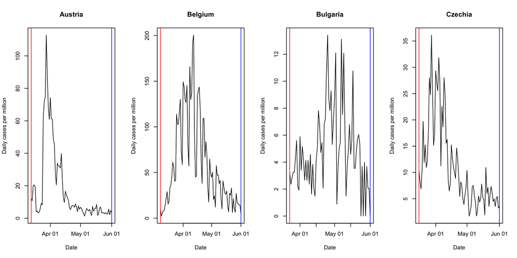

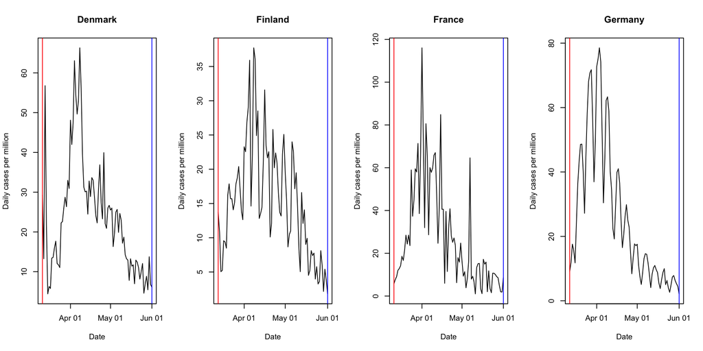

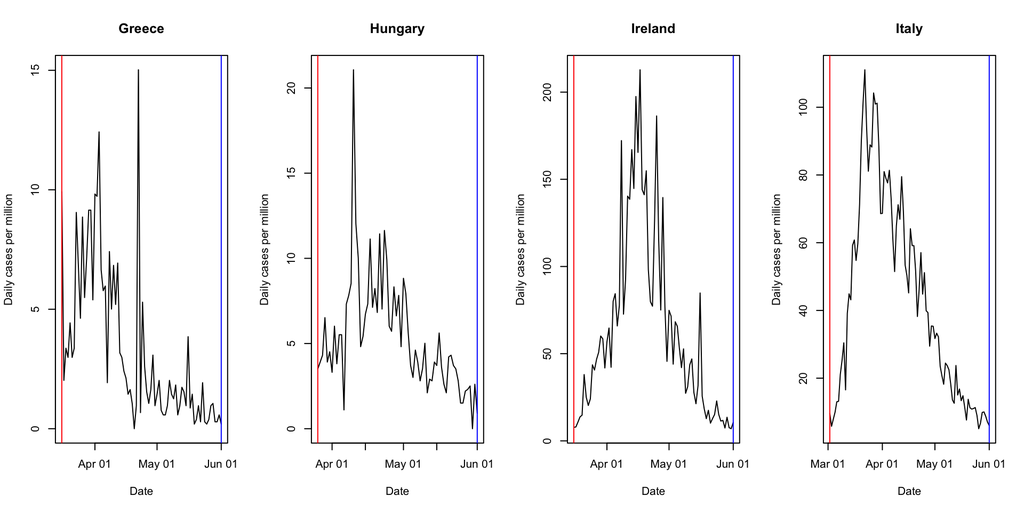

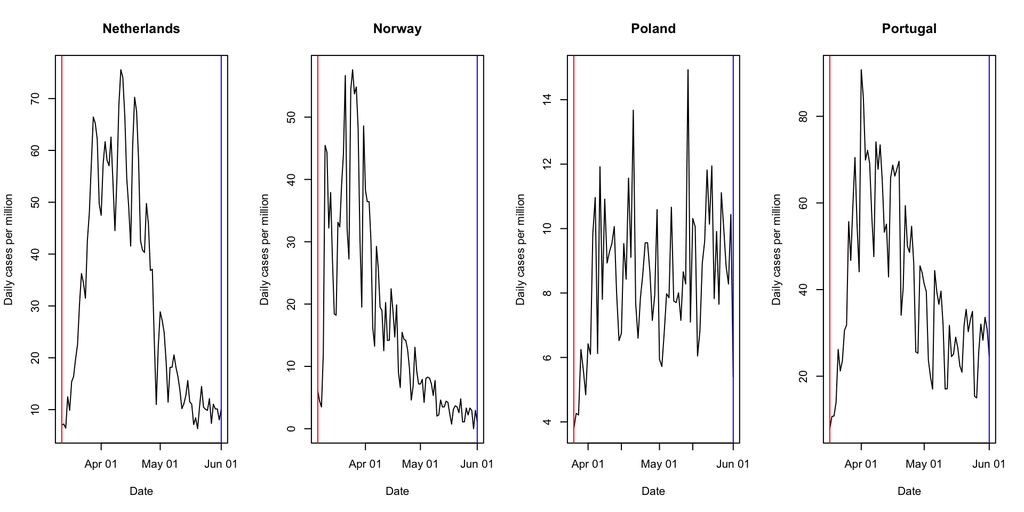

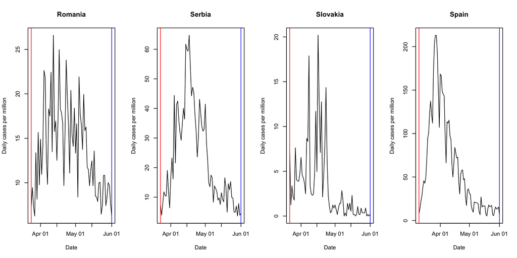

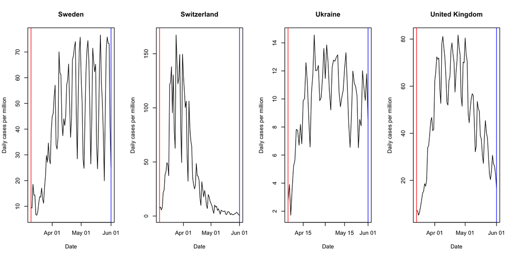

As seen above, we check that it matches quite nicely all the first waves of the pandemic, which is what we wanted. However, as each country has a different starting date, the curves plotted above do not have the same length, which is a necessary property to apply PCA. Therefore, we will use in the next section a B-Spline smoothing in order to solve this issue, as well as having nice differentiation properties.

# 3 B-Spline smoothing

In this section, we will use a b-spline basis and fit it to each curve to smooth it and then sample a set of values with the same length. Before using splines, we first had to remap the starting date to time zero and end date to $1$, with a linear mapping, which projects all the lines on the same domain $[0,1]$, but still had different lengths per country.

Mathematically, we can describe the B-Spline smoothing following [T. Masak - Functional Data Analysis](https://github.com/TMasak/AppStat/blob/main/Slides/11_functional_data.pdf). For a given country, let $\{y_i\}_{i=1,...,N}$ be noisy values of a function $f$ (which is the covid curve function in our case), evaluated at $\{x_i\}_{i=1,...,N} \in [0,T]$, the days in our case. Furthermore, let $\{\beta_i(x)\}_{i=1,...,q}$ be a set of basis functions chosen such that one can approximate
$$y(x) \approx \sum_{i=1}^q\xi_j \beta_j(x).$$
Then, by defining the optimization problem to find the $\xi$’s, as
$$\min_\xi \|y-B\xi\|_2^2, \text{ where } B = (\beta_j(x_n)),$$
we get $\hat{\xi} = (B^TB)^\dagger B^Ty$. Now, for a given set of evaluation points $\{z_i\}_{i=1,...,M}$, one gets $(f(z_1),f(z_2),...,f(z_M))^T \approx \tilde{B}\hat{\xi}$ where $\tilde{B} = (\beta_j(z_i))$, which are the smoothed evaluations from our function $f$ at each node.

Practically, we set the order of B-Splines to six, and set $\{z_i\}_{i=1,...,M}$ as the weekly nodes instead of the original daily nodes as it created stability issues for the smoothing when reaching $t=1$. Herunder are the smoothed functions plot using B-Spline smoothing :

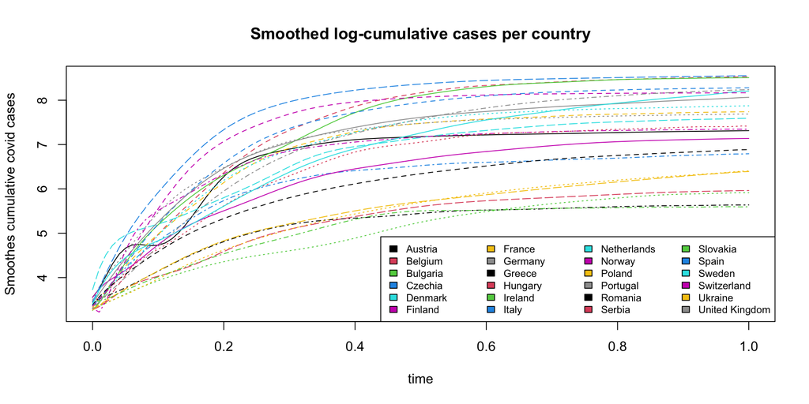

Now that we have those smoothed functions, with the same number of evaluations, we can start applying functional PCA and interpret the principal components.

# 4 Functional PCA

In this section, we apply Functional PCA on the $24 \times 100$ matrix previously computed, and extract its principal components.

Mathematically, let a given random sample $\{X_i\}_{i=1,...,N}$ with $X_i \in \mathbb{R}^p$ such that $\mathbb{E}[X_1^2]$. We define $\hat{\mu} = \frac{1}{N} \sum_{i=1}^N X_i \in \mathbb{R}^p$ and $\hat{C} = \frac{1}{N} \sum_{i=1}^N (X_i-\hat{\mu})(X_i-\hat{\mu})^T$. By eigendecomposition, we get $\hat{C} = \sum_{i=j}^{p \wedge N} \hat{\lambda}_j\hat{e}_j\hat{e}_j^T$. Now, for each sample, define $z_{i,j} = \hat{e}_j^T(X_i-\hat{\mu})$ which gives us
$$X_i = \hat{\mu} + \sum_{j=1}^{p \wedge N} z_{i,j}\hat{e}_j.$$
In practice, the process is as follows:

- Define $\tilde{X} := X - \hat{\mu} \in \mathbb{R}^{N \times p}$.
- Apply Singular Value Decomposition on $\tilde{X}$ such that $\tilde{X} = UDV^T$.
- Then, one gets $\hat{e}_j = V_{:,j}$ and $(z_{i,j})_{i,j} = UD$ are the scores.

The first row of the plots below represent the mean of the log-cumulative total cases for $0 \le t \le 1$ (left), and the scores of each country with respect to the first two principal components (right). The next four plots represent the principal components, and we compute the percentage of total variance explained (see title of figures).

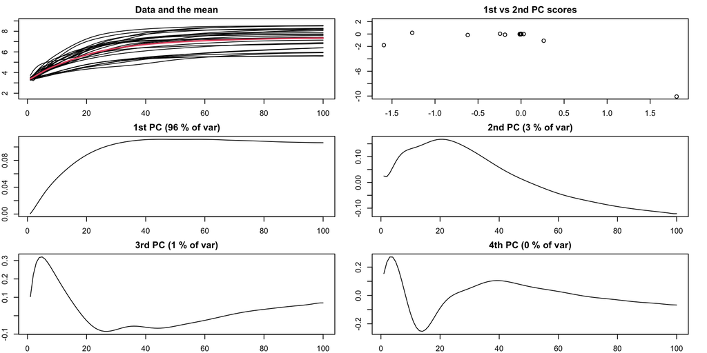

First, we observe on the top-left plot the red line which represent the mean of log-cumulative number of covid cases for the $24$ retained European countries for $0 \le t \le 1$. We observe a sort of square root increase and a stabilization around $t = 0.7$. Regarding the interpretation of our principal components, we get:

1. The first one starts at $0$ for $t=0$, then shows a growth and stabilization at $t = 0.4$. If the score of a country is positive for this PC, it can be interpreted as a quicker rise of covid cases, followed by a positive stabilization above the mean after $t=0.4$. However if the score is negative, it means that the country had a slower rise of covid cases compared to other countries, and are generally below the mean after $t=0.4$.
2. The second one starts at a non-zero value for $t=0$, shows a first increase up to $t=0.2$, following by a steep decrease until the end, even entering negative values. If a country has a positive coefficient for the second PC, it means that it originally started above the mean (non-zero positive value at $t=0$), then rose even quicker up to $t=0.2$, then reverted to the mean (up to reaching the x-axis), and finally crossing the mean to be below par, as $t$ reaches $1$.
3. The third one also starts at non-zero value, then shows a quicker growth than PC2 up to $t=0.1$. Then, it steeply decreases up to negative values until $t=0.25$, where it starts to linearly increase again. This PC is more complex than the previous ones. If a country has a positive coefficient for the third PC, it means that it originally started above the mean (non-zero positive value at $t=0$), then rose quicker up to $t=0.1$, then steeply reversed and even crossed the mean up to $t=0.25$, before linearly growing, reaching back the mean at $t=0.6$ and continuing rising above the mean up to $t=1$. For negative coefficients, one can simply invert the analysis above to find the behaviour.
4. The fourth PC and last PC analyzed here also shows a complex behaviour, with non-zero start followed by a quick increase before dropping steeply up to $t=0.15$ to negative values. Between $t=0.15$ and $t=0.4$, it increases again to end up slighlty above the mean, before linearly decreasing up to $t=1$.

Regarding the scores of the countries for the first two PCs, one gets the GDP of each retained country for $2019$, we can plot those PC scores and apply the GDP as a color to the datapoints on a scatter plot :

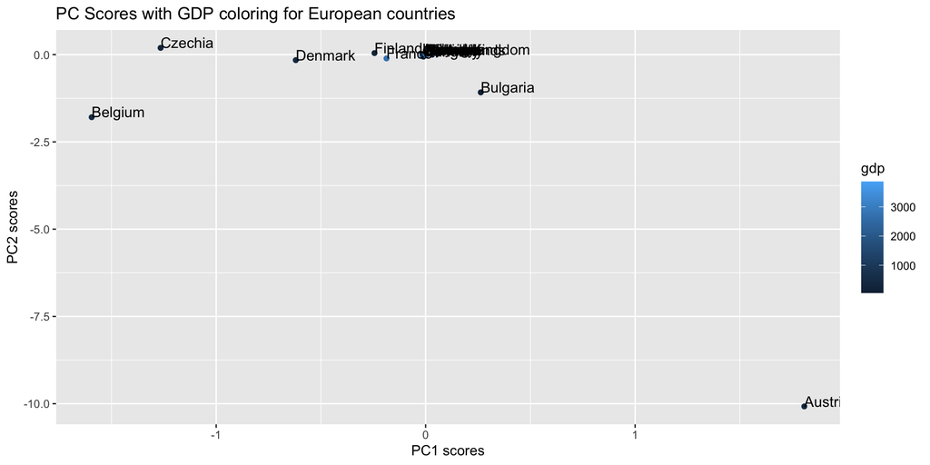

As seen above, we observe a strong concentration of the PC scores around the $(0,0)$ point. This means that the majority of the countries are not too far from the mean (as seen on the top-left plot from the previous figure). We observe two outliers from this plot : Austria and Belgium, for which we plot the mean hereunder for more clarity.

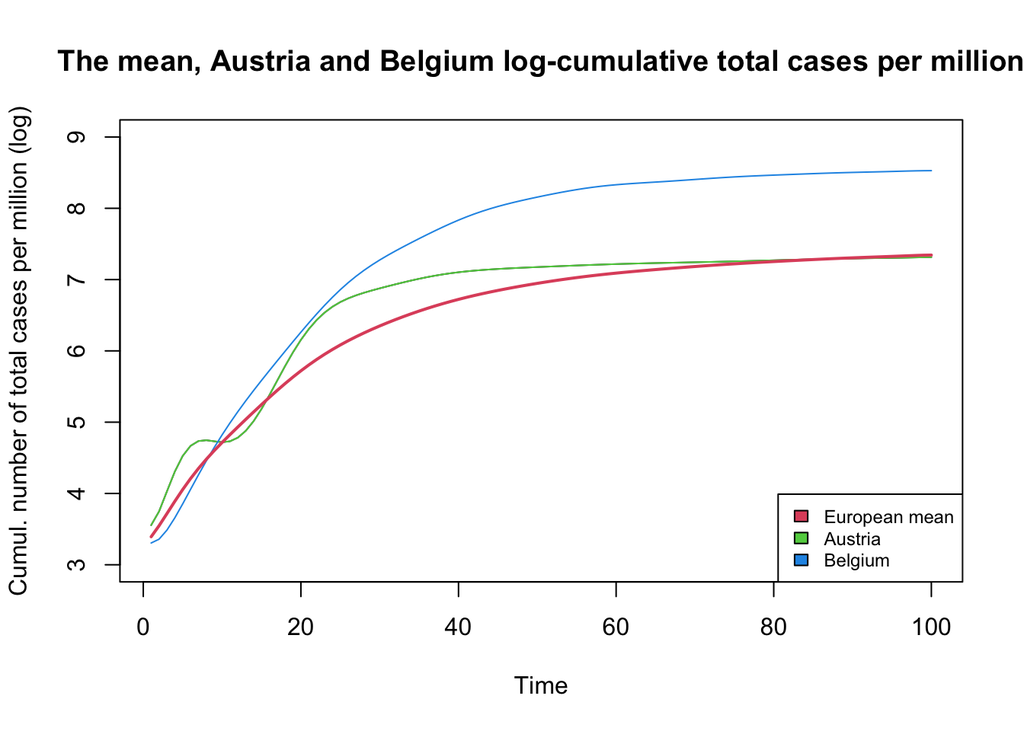

# 5 Conclusion

In conclusion, we used Functional Principal Component Analysis to understand a bit better how the first wave of covid hit Europe in early $2020$. We used the B-Spline smoothing method to enable us comparing all covid curves which initially had different lengths and apply PCA on it. We observed several intersting principal components which explain deviation behaviours from the mean, as well as two outliers which we dig up on. The next steps for this project would be to analyse the covid spreading speed, as well as acceleration over European countries, and then compare it to other continents.